# neualNetSales

Jacky/Dottie Maya

11/01/2019

# 1 Introduction

This is an application of a neural network designed to identify characterists of car buyers. The purose is to direct advertising

**ASSIGNMENT:**  
1. Find the ‘best’ sales target price for predicting sales -  
2. Determing values of age, gender, income level or commute distance *i.e.* miles/wk that predict best sales  
3. Determing the appropriate neural net - how many hidden layers, what variables to leave out?  
4. Does it help to use 80/20 (or any other) split for training/test sets?  
5. Recommend an advetising approach based on your findings

## 1.1 first set up the environment

## 1.2 table .. description of the data

The data set contains information about car buyers

| Variable | Description |
| --- | --- |
| age | age of the buyer |
| gender | sex of the buyer |
| miles | average number of miles driven per day |
| debt | current debt of the buyer |
| income | buyer montly income |
| sales | amount spent on a used car |

## 1.3 print the first 6 entries of the cars data set

=====  
set the target price for sales  
=====

```r
salesTargetPrice = 20000
summary(cars$sales)
```

```
##    Min. 1st Qu.  Median    Mean 3rd Qu.    Max.
##     500    3554    9130   11690   19245   29926
```

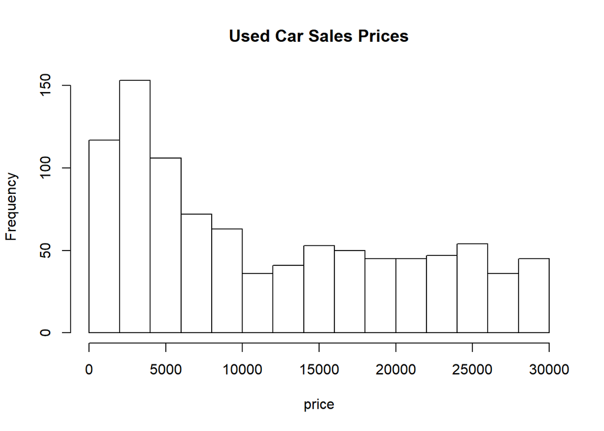

```r
hist(cars$sales, xlab='price', main='Used Car Sales Prices')
```

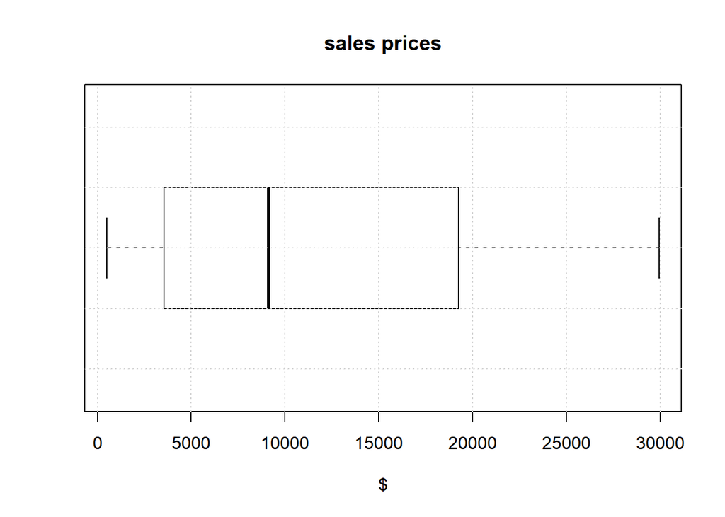

```r
boxplot(cars$sales, main='sales prices',horizontal = TRUE, xlab='$')
grid()
```

```r
# set up 'yes / no' based on sales price salesTargetPrice
cars$salesTgt = ifelse(cars$sales>salesTargetPrice,1,0)
head(cars)
```

```
##   age gender miles  debt income sales salesTgt
## 1  28      0    23     0   4099   620        0
## 2  26      0    27     0   2677  1792        0
## 3  30      1    58 41576   6215 27754        1
## 4  26      1    25 43172   7626 28256        1
## 5  20      1    17  6979   8071  4438        0
## 6  58      1    18     0   1262  2102        0
```

# 2 Set up the Training and Test data

=====  
set the training fraction  
=====

```r
##set up the training and test data:
trainingFraction = 0.70
lengthData = length(cars$age) #  how many entries in the data set
nTrain = round(trainingFraction*lengthData,0)
nTest = lengthData-nTrain
# shuffle the data, take the first nTrain as the training set, the
# remainder as the test set
shuffle = sample(1:lengthData, replace=FALSE)
#set up the test and train objects
testDataSet = vector("numeric", length=nTest)
trainDataset= vector("numeric", length=nTrain)
trainIndex = shuffle[1:nTrain]
trainDataSet = cars[shuffle[1:nTrain],]
testIndex = vector("numeric")
testIndex = shuffle[-trainIndex]
testDataSet = cars[shuffle[-trainIndex],]
head(trainDataSet)
```

```
##     age gender miles  debt income sales salesTgt
## 359  48      0    13   963   2021  2526        0
## 411  30      0    44 20245  10491 20638        1
## 431  49      0    24  6446   5304 11339        0
## 949  38      0    48 25611  11694 21989        1
## 169  41      0    29 12317   9438 18904        0
## 799  42      1    41   837   8509 16793        0
```

Set up normalized set– based on the test set

```r
meanAge = mean(testDataSet$age)
sdAge = sd(testDataSet$age)
meanMiles = mean(testDataSet$miles)
sdMiles = sd(testDataSet$miles)
meanDebt = mean(testDataSet$debt)
sdDebt = sd(testDataSet$debt)
meanIncome = mean(testDataSet$income)
sdIncome = sd(testDataSet$income)
#normalize age, miles, debt, income, and sales
## normalize the entire data set based on the test set..
carsNormalized = cars
carsNormalized$age = (cars$age-meanAge)/sdAge
carsNormalized$miles = (cars$miles-meanMiles)/sdMiles
carsNormalized$debt = (cars$debt - meanDebt)/sdDebt
carsNormalized$income = (cars$income-meanIncome)/sdIncome
carsNormalized$salesTgt = cars$salesTgt
normalizedTrainDataSet= carsNormalized[shuffle[trainIndex],]
normalizedTestDataSet = carsNormalized[shuffle[-trainIndex],]
head(normalizedTrainDataSet)
```

```
##             age gender       miles        debt     income sales salesTgt
## 390  1.09753242      0  1.23179752 -0.05218381  1.3073126 20129        1
## 497  0.08911244      1 -0.55319444 -0.63207007  0.3764431 11413        0
## 164  0.94239089      0  0.06767233 -0.26607267  0.1726009  6142        0
## 534 -1.46230292      1 -0.94123617 -0.27902394  1.4254993  4827        0
## 395 -0.68659524      0 -0.47558609 -0.73143663 -1.3721829  2832        0
## 716 -0.22117063      0  1.54223090 -0.28552713  1.2959715 17038        0
```

# 3 what factors may be in play??

```r
linearModel = glm(sales~ age + gender + miles + debt + income, data = trainDataSet)
summary(linearModel)
```

```
##
## Call:
## glm(formula = sales ~ age + gender + miles + debt + income, data = trainDataSet)
##
## Deviance Residuals:
##     Min       1Q   Median       3Q      Max
## -9942.1  -2408.9   -392.5   2144.5  16090.4
##
## Coefficients:
##               Estimate Std. Error t value Pr(>|t|)
## (Intercept) -3.951e+03  5.606e+02  -7.049 4.50e-12 ***
## age          8.927e+01  1.220e+01   7.316 7.33e-13 ***
## gender      -2.588e+02  2.876e+02  -0.900    0.369
## miles        1.254e+02  1.367e+01   9.177  < 2e-16 ***
## debt         2.837e-01  1.011e-02  28.064  < 2e-16 ***
## income       8.057e-01  5.308e-02  15.179  < 2e-16 ***
## ---
## Signif. codes:  0 '***' 0.001 '**' 0.01 '*' 0.05 '.' 0.1 ' ' 1
##
## (Dispersion parameter for gaussian family taken to be 13919738)
##
##     Null deviance: 5.4342e+10  on 673  degrees of freedom
## Residual deviance: 9.2984e+09  on 668  degrees of freedom
## AIC: 13007
##
## Number of Fisher Scoring iterations: 2
```

```r
print(linearModel)
```

```
##
## Call:  glm(formula = sales ~ age + gender + miles + debt + income, data = trainDataSet)
##
## Coefficients:
## (Intercept)          age       gender        miles         debt
##  -3951.4349      89.2748    -258.7718     125.4464       0.2837
##      income
##      0.8057
##
## Degrees of Freedom: 673 Total (i.e. Null);  668 Residual
## Null Deviance:       5.434e+10
## Residual Deviance: 9.298e+09     AIC: 13010
```

leave gender out

# 4 Traditional stat approach: Logistic Regression

```r
logisticModel = glm(salesTgt ~ age + miles + debt + income, family=binomial, data = trainDataSet)
summary(logisticModel)
```

```
##
## Call:
## glm(formula = salesTgt ~ age + miles + debt + income, family = binomial,
##     data = trainDataSet)
##
## Deviance Residuals:
##      Min        1Q    Median        3Q       Max
## -2.57174  -0.22185  -0.11928  -0.05405   2.86463
##
## Coefficients:
##               Estimate Std. Error z value Pr(>|z|)
## (Intercept) -7.693e+00  1.086e+00  -7.081 1.43e-12 ***
## age          2.349e-03  1.839e-02   0.128  0.89837
## miles        6.013e-02  1.905e-02   3.156  0.00160 **
## debt         1.409e-04  1.340e-05  10.516  < 2e-16 ***
## income       2.436e-04  8.438e-05   2.887  0.00389 **
## ---
## Signif. codes:  0 '***' 0.001 '**' 0.01 '*' 0.05 '.' 0.1 ' ' 1
##
## (Dispersion parameter for binomial family taken to be 1)
##
##     Null deviance: 743.41  on 673  degrees of freedom
## Residual deviance: 193.26  on 669  degrees of freedom
## AIC: 203.26
##
## Number of Fisher Scoring iterations: 7
```

```r
b = as.numeric(logisticModel$coefficients)
```

## 4.1 quick look- general probability of a sale

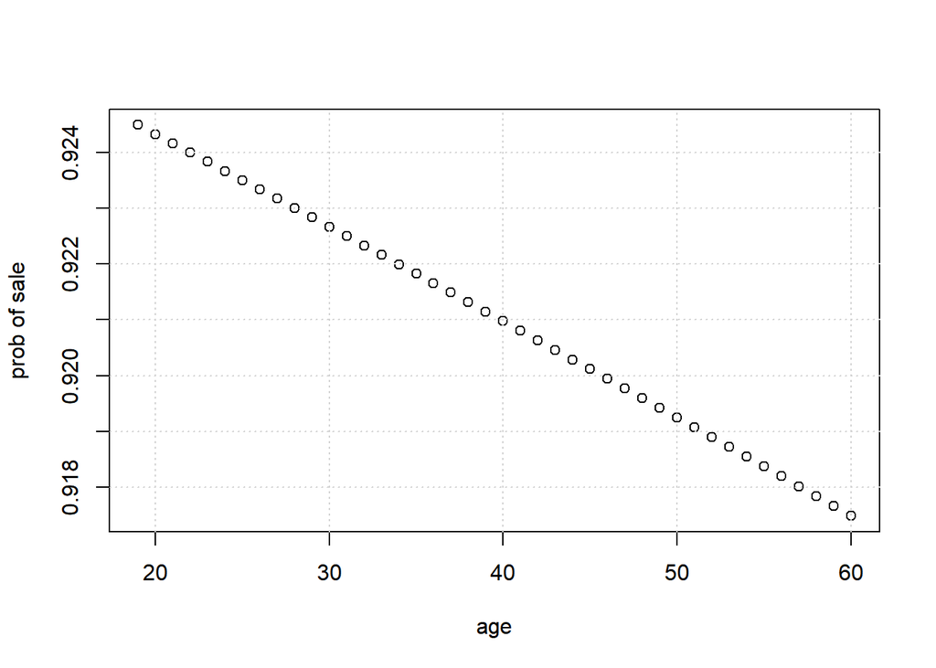

```r
# use average values for debt, income, and miles driven/wk
averageDebt = mean(testDataSet$debt)
averageIncome = mean(testDataSet$income)
averageMiles = mean(testDataSet$miles)
# logistic regresson coefficients from previous chunk
xx = b[1]+b[2]*testDataSet$age + b[3]*averageMiles +
  b[4]*averageDebt + b[5]*averageIncome
pred.prob = 1./(1+exp(xx))
plot(testDataSet$age, pred.prob, ylab='prob of sale', xlab='age')
grid()
```

## 4.2 Cross tabulation of logistic regression predictions

columns are ‘truth,’ rows are predictions

```
##      [,1] [,2]
## [1,]    0    0
## [2,]  222   67
```

```
## [1] "columns are truth in data set, "
```

```
## [1] "rows are predicted by logistic regression "
```

```
## [1] "Overall accuracy: 23%"
```